# Ejercicio 15

# Ejercicio: Proyecto Molibdeno

## Enunciado

Ha recibido Vd. esta carta. Adopte el papel del destinatario y actúe en consecuencia justificando sus decisiones.

> Estimado Director de Proyectos:

> En relación con nuestra anterior conversación telefónica, le adjunto los detalles del proyecto “Molibdeno”, del que ha pasado a ser máximo responsable, y sobre el que cuelga la amenaza de sufrir retrasos. Como ya habrá leído en nuestra última circular, a fin de salvar el bache económico actual, su correcta gestión económica es de vital importancia, pues la nefasta gestión del responsable de la negociación del contrato nos carga con unas penalizaciones por retraso de diez u.m./periodo, doble de lo habitual en este tipo de proyectos.

> Le anticipo una buena noticia. Con el cambio de Director de Proyecto, también cambiaremos de contratista principal para desarrollar las tareas del proyecto que restan por comenzar. La empresa anterior, “Borum”, dispone de una plantilla limitada, 150 técnicos, y eso le impide aceptar modificaciones en relación con las tareas ya comenzadas. El nuevo contratista, “Calcium”, dispone de 200 técnicos y nos asegura su disponibilidad y cooperación frente a cualquier modificación respecto a la planificación inicial.

> El Consejo de Administración desea tener en cuenta su valoración acerca de la actuación del anterior gestor, así como también agradecería que le proporcionara una enumeración justificada de las actuaciones que llevará a cabo a efectos de gestionar correctamente el proyecto.

> Reciba un cordial saludo.

Los datos del proyecto son los siguientes:

| actividad | Precedente | Duración planificada | Duración real | Coste planificado | Coste real | Coste duración tope | Duración tope | Porcentaje realizado | Recursos | Varianza | Duración pesimista |
| --- | --- | --- | --- | --- | --- | --- | --- | --- | --- | --- | --- |
| A | --- | 5 | 7 | 70 | 77 | 100 | 2 | 100 | 5 | 1 | 15 |
| B | --- | 3 | 8 | 48 | 56 | 58 | 1 | 100 | 10 | 2 | 9 |
| C | --- | 4 | 5 | 40 | 45 | 66 | 2 | 100 | 15 | 3 | 12 |
| D | B | 4 | 5 | 40 | 50 | 94 | 2 | 100 | 5 | 9 | 12 |
| E | B | 3 | 3 | 18 | 21 | 37 | 1 | 100 | 15 | 5 | 9 |
| F | B | 3 | 4 | 36 | 40 | 58 | 1 | 100 | 15 | 4 | 9 |
| G | A, D | 4 | 6 | 96 | 90 | 111 | 1 | 100 | 10 | 6 | 12 |
| H | F | 4 | 6 | 48 | 42 | 120 | 2 | 100 | 5 | 7 | 12 |
| I | C, E | 6 | 7 | 210 | 189 | 140 | 3 | 100 | 5 | 3 | 18 |
| J | C, E, F, G | 5 | 3 | 45 | 42 | 188 | 1 | 100 | 15 | 2 | 15 |
| K | H, I | 7 | 4 | 63 | 40 | 211 | 1 | 50 | 15 | 5 | 21 |
| L | H, I | 5 | 4 | 75 | 72 | 194 | 1 | 40 | 15 | 6 | 15 |
| M | H, I | 6 | 4 | 36 | 32 | 188 | 1 | 80 | 15 | 9 | 18 |
| N | H, I | 9 | 4 | 54 | 52 | 188 | 1 | 50 | 15 | 5 | 27 |
| O | J, K | 4 | --- | 60 | --- | 76 | 2 | 0 | 10 | 3 | 12 |
| P | L | 3 | --- | 21 | --- | 35 | 1 | 0 | 15 | 6 | 9 |
| Q | M | 3 | --- | 33 | --- | 49 | 1 | 0 | 15 | 5 | 9 |
| R | N | 3 | --- | 39 | --- | 49 | 1 | 0 | 10 | 6 | 9 |
| S | O | 3 | --- | 36 | --- | 48 | 1 | 0 | 10 | 2 | 9 |
| T | S | 3 | --- | 18 | --- | 32 | 1 | 0 | 10 | 6 | 9 |
| U | P | 3 | --- | 12 | --- | 18 | 1 | 0 | 10 | 4 | 9 |
| V | Q | 4 | --- | 12 | --- | 20 | 2 | 0 | 10 | 8 | 12 |
| W | R | 3 | --- | 12 | --- | 18 | 1 | 0 | 10 | 2 | 9 |
| X | W | 4 | --- | 12 | --- | 30 | 2 | 0 | 5 | 5 | 12 |

## Solución

### Grafo PERT de la planificación inicial

Cálculo de los tiempos tempranos y tardíos de los sucesos y de las holguras totales paso a paso. El primer paso muestra el grafo resuelto; a partir del siguiente se calcula desde el principio (avance con los botones):

[figure not shown]

paso 0 de 64

[figure not shown]

Pert de la planificación inicial

Camino crítico (la ruta de mayor duración; sus actividades tienen holgura total nula):

- **B – E – I – N – R – W – X**: 3 + 3 + 6 + 9 + 3 + 3 + 4 = **31** periodos

**Duración del proyecto: 31 periodos.**

El proyecto tenía una duración prevista de 31 periodos. Como alternativa al grafo PERT podemos representar el diagrama de Gantt.

### Diagrama de Gantt

[figure not shown]

Gantt de la planificación inicial

### Demanda de recursos

Hecho el diagrama de Gantt anterior resulta fácil comprobar si la demanda de recursos supone alguna dificultad en algun momento del proyecto.

[figure not shown]

Demanda de recursos en el tiempo

La fila *Total* del Gantt de recursos suma, en cada periodo, los técnicos de las actividades en curso. La demanda máxima es de **75 técnicos** (periodos 13, 14, 15 y 16), frente a los 150 técnicos de Borum y los 200 de Calcium: 50% y 38% de sus plantillas.

Perfil de la demanda de recursos en el tiempo

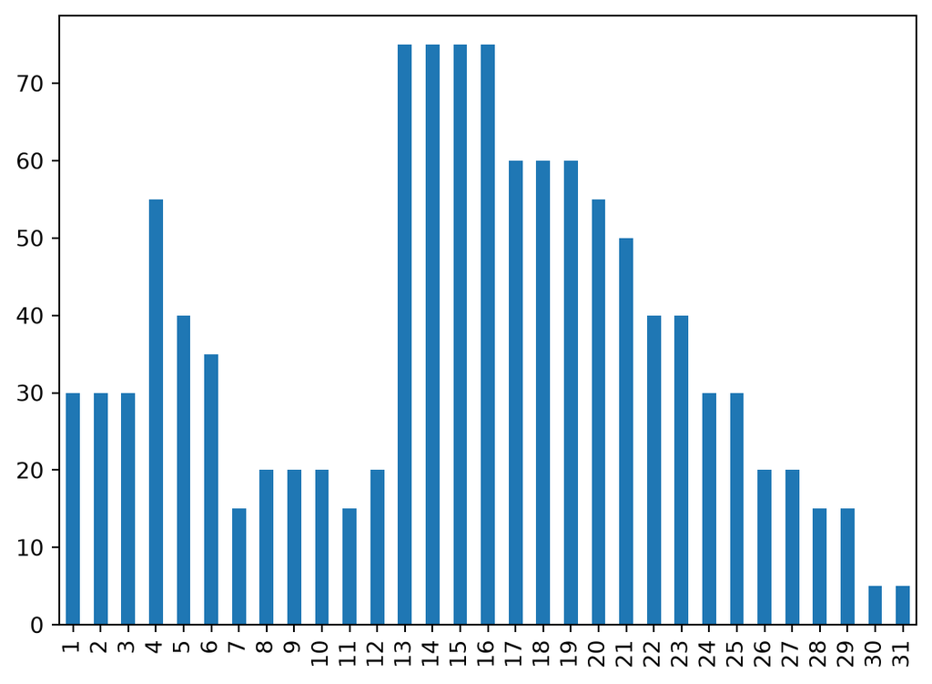

Estos resultados confirman que el uso de recursos no presenta ningún problema en este proyecto, ni con la plantilla del contratista anterior ni con la del nuevo, por ser muy inferior a la plantilla disponible de técnicos.

### Método del valor ganado

La evaluación del estado actual del proyecto puede realizarse a través del método del valor ganado. Para ello se utilizará el diagrama de Gantt mostrado anteriormente y el correspondiente a las duraciones reales.

[figure not shown]

Gantt de los trabajos realizados

[figure not shown]

PV: Valor planificado

[figure not shown]

AC: Coste real

[figure not shown]

EV: Valor ganado

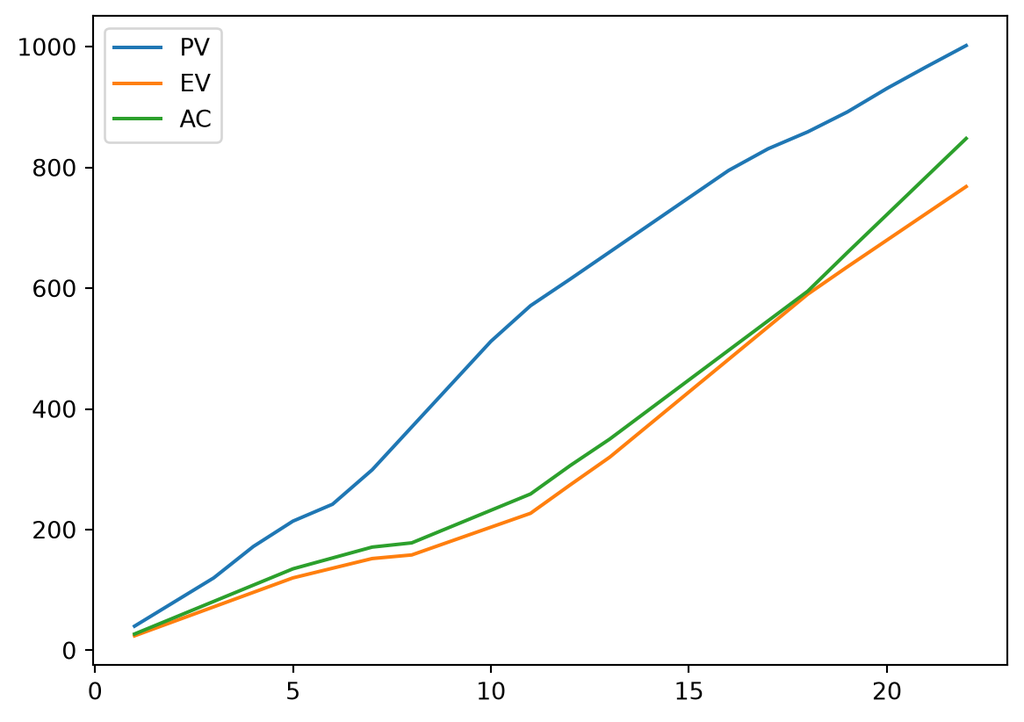

Evolución en el tiempo de los parámetros del método del valor ganado

En el punto de control, los valores de PV, AC, EV son:

|  | PV | EV | AC |
| --- | --- | --- | --- |
| 22 | 1002.0 | 768.3 | 848.0 |

La fecha de control es el periodo 22 (fin del Gantt de duraciones reales). Con PV (valor planificado), EV (valor ganado = Σ % realizado × coste planificado) y AC (coste real):

- CPI (índice de rendimiento del coste) = EV / AC = 768.3 / 848 = **0.906**; CV (variación del coste) = EV − AC = -79.7.

- SPI (índice de rendimiento del plazo) = EV / PV = 768.3 / 1002 = **0.767**; SV (variación del plazo) = EV − PV = -233.7.

CPI < 1: hay sobrecoste (por cada u.m. gastada se ha obtenido 0.91 u.m. de valor) y SPI < 1: hay retraso (se ha ejecutado el 77% de lo que debía estar hecho en el periodo 22).

Desviaciones de las actividades terminadas: duran más de lo previsto A, B, C, D, F, G, H y I y cuestan más de lo previsto A, B, C, D, E y F:

| actividad | duración plan. | duración real | retraso | coste plan. | coste real | sobrecoste |
| --- | --- | --- | --- | --- | --- | --- |
| A | 5 | 7 | 2 | 70 | 77 | 7 |
| B | 3 | 8 | 5 | 48 | 56 | 8 |
| C | 4 | 5 | 1 | 40 | 45 | 5 |
| D | 4 | 5 | 1 | 40 | 50 | 10 |
| E | 3 | 3 | 0 | 18 | 21 | 3 |
| F | 3 | 4 | 1 | 36 | 40 | 4 |
| G | 4 | 6 | 2 | 96 | 90 | -6 |
| H | 4 | 6 | 2 | 48 | 42 | -6 |
| I | 6 | 7 | 1 | 210 | 189 | -21 |
| J | 5 | 3 | -2 | 45 | 42 | -3 |

**Valoración de la actuación del anterior gestor:** el análisis del valor ganado (CPI < 1 y SPI < 1) indica que el proyecto va con retraso y sobrecoste; la gestión ha sido deficiente tanto en plazo como en coste.

### Cálculo de la duración prevista del proyecto

Para el cálculo de la duración prevista a la luz de la información recogida se asume que para: - las actividades ya terminadas se utilizará su duración real; - las actividades comenzadas pero no completadas lo harán a la velocidad seguida hasta ahora; - las actividades que no han comenzado, su duración prevista es la correspondiente a la planificación inicial.

Las actividades en curso mantienen su ritmo: si en su duración real han completado el % realizado, su duración total prevista es 100 × duración real / % realizado:

- K: 100 × 4 / 50 = **8** periodos (planificada: 7; quedan 4)

- L: 100 × 4 / 40 = **10** periodos (planificada: 5; quedan 6)

- M: 100 × 4 / 80 = **5** periodos (planificada: 6; quedan 1)

- N: 100 × 4 / 50 = **8** periodos (planificada: 9; quedan 4)

Las terminadas toman su duración real y las no empezadas conservan la planificada.

Una vez obtenidas las duraciones previstas de las actividades, se puede calcular la nueva fecha de fin de proyecto.

Cálculo de los tiempos tempranos y tardíos de los sucesos y de las holguras totales paso a paso. El primer paso muestra el grafo resuelto; a partir del siguiente se calcula desde el principio (avance con los botones):

[figure not shown]

paso 0 de 64

[figure not shown]

Pert de la previsión a futuro del proyecto

El proyecto presenta ahora una nueva duración de 36 periodos. De modo alternativo, se puede llegar a igual resultado representando el diagrama de Gantt.

[figure not shown]

Gantt de la previsión a futuro del proyecto

### Análisis de los costes incurridos por penalización vs. los costes derivados de la reducción de la duración del proyecto

Esta nueva situación tiene como consecuencia un retraso de 5 periodos con respecto a la planificación inicial. Dadas las penalizaciones por retraso del enunciado, las actuaciones del Director del Proyecto irán encaminadas a paliar el efecto negativo de este retraso. Para analizar de manera más simple la situación actual y presentar una estrategia de actuación se considera únicamente la parte de proyecto que resta por terminar.

Construcción del resto del proyecto, a partir de la fecha de control (periodo 22):

- Se eliminan las actividades terminadas; las que tenían predecesoras terminadas dejan de tenerlas (por eso K, L, M y N no tienen precedentes y O solo depende de K).

- Actividades en curso (K, L, M y N): duración restante = (100 − % realizado) × duración real / % realizado (K: (100 − 50) × 4 / 50 = 4; L: (100 − 40) × 4 / 40 = 6; M: (100 − 80) × 4 / 80 = 1; N: (100 − 50) × 4 / 50 = 4). Las ejecuta Borum, que no acepta modificaciones: no se pueden acortar (coste unitario de reducción infinito).

- Actividades no empezadas (las hará Calcium): coste unitario de reducción cur = (coste a duración tope − coste planificado) / (duración − duración tope):

  - O: (76 − 60) / (4 − 2) = **8** u.m./periodo

  - P: (35 − 21) / (3 − 1) = **7** u.m./periodo

  - Q: (49 − 33) / (3 − 1) = **8** u.m./periodo

  - R: (49 − 39) / (3 − 1) = **5** u.m./periodo

  - S: (48 − 36) / (3 − 1) = **6** u.m./periodo

  - T: (32 − 18) / (3 − 1) = **7** u.m./periodo

  - U: (18 − 12) / (3 − 1) = **3** u.m./periodo

  - V: (20 − 12) / (4 − 2) = **4** u.m./periodo

  - W: (18 − 12) / (3 − 1) = **3** u.m./periodo

  - X: (30 − 12) / (4 − 2) = **9** u.m./periodo

| actividad | precedente | duracion | duracion_tope | cur |
| --- | --- | --- | --- | --- |
| K | ---- | 4 | 1 | inf |
| L | ---- | 6 | 1 | inf |
| M | ---- | 1 | 1 | inf |
| N | ---- | 4 | 1 | inf |
| O | K | 4 | 2 | 8.0 |
| P | L | 3 | 1 | 7.0 |
| Q | M | 3 | 1 | 8.0 |
| R | N | 3 | 1 | 5.0 |
| S | O | 3 | 1 | 6.0 |
| T | S | 3 | 1 | 7.0 |
| U | P | 3 | 1 | 3.0 |
| V | Q | 4 | 2 | 4.0 |
| W | R | 3 | 1 | 3.0 |
| X | W | 4 | 2 | 9.0 |

Cálculo de los tiempos tempranos y tardíos de los sucesos y de las holguras totales paso a paso. El primer paso muestra el grafo resuelto; a partir del siguiente se calcula desde el principio (avance con los botones):

[figure not shown]

paso 0 de 40

[figure not shown]

Pert del resto del proyecto por completar

A fin de paliar el efecto del retraso y no pagar un exceso en penalizaciones, se considera la reducción de la duración del proyecto con mínimo coste.

[figure not shown]

paso -1 de 5

[figure not shown]

Algoritmo de Ackoff-Sasieni: tabla completa. Pulse «siguiente» para ver cómo se construye.

La comparativa de costes entre la opción de recortar el proyecto y la opción de pagar las penalizaciones es la siguiente.

Sin actuar, el proyecto terminaría en el periodo 22 + 14 = 36 (duración del resto: 14 periodos), 5 periodos después de lo previsto (31); la penalización sería 10 × (36 − 31) = 50 u.m. Cada periodo que se acorta ahorra 10 u.m. de penalización; el algoritmo de Ackoff-Sasieni da la combinación más barata para cada periodo de reducción:

- Periodo 1 (de 36 a 35): acortar S y W cuesta 6 + 3 = 9 u.m. < 10: compensa

- Periodo 2 (de 35 a 34): acortar S y W cuesta 6 + 3 = 9 u.m. < 10: compensa

- Periodo 3 (de 34 a 33): acortar R, T y U cuesta 5 + 7 + 3 = 15 u.m. ≥ 10: no compensa

- Periodo 4 (de 33 a 32): acortar R, T y U cuesta 5 + 7 + 3 = 15 u.m. ≥ 10: no compensa

- Periodo 5 (de 32 a 31): acortar O, P y X cuesta 8 + 7 + 9 = 24 u.m. ≥ 10: no compensa

Coste total = coste de reducción acumulado + penalización, con penalización = 10 × (duración − 31):

| duracion | Coste de Reducción | Coste de Reducción Acumulado | Penalizacion | Costes Totales |
| --- | --- | --- | --- | --- |
| 36 | 0.0 | 0.0 | 50 | 50.0 |
| 35 | 9.0 | 9.0 | 40 | 49.0 |
| 34 | 9.0 | 18.0 | 30 | 48.0 |
| 33 | 15.0 | 33.0 | 20 | 53.0 |
| 32 | 15.0 | 48.0 | 10 | 58.0 |
| 31 | 24.0 | 72.0 | 0 | 72.0 |

La suma de costes agregados resultante de sumar los costes de reducción acumulados más los costes de penalización acumulados indican que la operación más ventajosa desde el punto de vista de estos costes es reducir el proyecto hasta dejar su duración en 34 periodos.

**Respuesta al Consejo de Administración**

*Valoración del anterior gestor.* En la fecha de control (periodo 22) el proyecto va con sobrecoste (CPI = 0.906, AC − EV = 79.7 u.m. gastadas de más) y con retraso (SPI = 0.767, falta trabajo por valor de 233.7 u.m. respecto al plan). Al ritmo actual el proyecto terminaría en el periodo 36 en lugar del 31: 5 periodos de retraso y 50 u.m. de penalización.

*Actuaciones:*

1. No modificar las actividades en curso (K, L, M y N): Borum no acepta cambios en ellas.

2. Con Calcium, acortar las actividades no empezadas S (2 periodos) y W (2 periodos), con un coste de reducción de 18 u.m.: el proyecto terminará en el periodo 34 y la penalización será 10 × (34 − 31) = 30 u.m. Coste total: 18 + 30 = **48 u.m.**, frente a 50 u.m. sin actuar. Seguir acortando no compensa: el siguiente periodo cuesta 15 u.m. y solo ahorra 10 u.m. de penalización.

3. Los recursos no limitan estas decisiones: la demanda máxima del plan (75 técnicos) está muy por debajo de las plantillas de Borum (150) y Calcium (200).

4. Controlar el resto del proyecto con el valor ganado (CPI y SPI) en cada periodo para detectar a tiempo nuevas desviaciones.